# EEZs for Aquaculture on the West Coast

Author

Lauren Puffer

Published

November 25, 2025

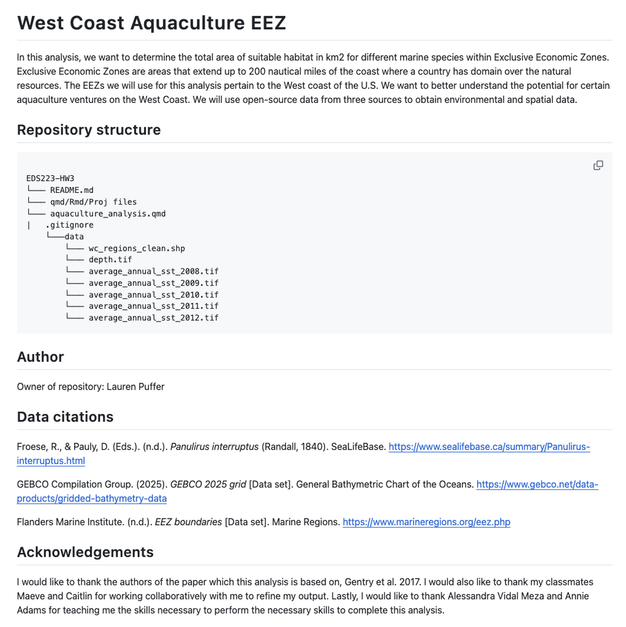

# Introduction

In this analysis, we want to determine the total area of suitable habitat in km2 for different marine species within Exclusive Economic Zones. Exclusive Economic Zones are areas that extend up to 200 nautical miles of the coast where a country has domain over the natural resources. The EEZs we will use for this analysis pertain to the West coast of the U.S. We want to better understand the potential for certain aquaculture ventures on the West Coast. We will use open-source data from three sources to obtain environmental and spatial data.

# Data citations

GEBCO Compilation Group. (2025). *GEBCO 2025 grid* [Data set]. General Bathymetric Chart of the Oceans. https://www.gebco.net/data-products/gridded-bathymetry-data

Flanders Marine Institute. (n.d.). *EEZ boundaries* [Data set]. Marine Regions. https://www.marineregions.org/eez.php

Sea Life Base: https://www.sealifebase.ca/search.php

# Load libraries

```r
library(tidyverse)
library(sf)
library(terra)
library(tmap)
library(patchwork)
library(here)
library(dplyr)
```

# Load data

The files we will be loading are mostly raster (annual sea surface temperature and bathymetry) and a shapefile with the boundaries of Exclusive Economic Zones.

```r
# Read in shapefile of EEZs
eez <- st_read(here("data", "wc_regions_clean.shp"))
```

## Sea surface temperature

The following files contain mean sea surface temperature across 5 different years from 2008 to 2012. These temperatures will be averaged later on in the analysis after stacking all 5 rasters.

```r
# Read in rasters of sea surface temerpature
sst_2008 <- rast(here("data", "average_annual_sst_2008.tif"))
sst_2009 <- rast(here("data", "average_annual_sst_2009.tif"))
sst_2010 <- rast(here("data", "average_annual_sst_2010.tif"))
sst_2011 <- rast(here("data", "average_annual_sst_2011.tif"))
sst_2012 <- rast(here("data", "average_annual_sst_2012.tif"))
```

## Bathymetry

This raster conatins a grid profile of depths in the ocean. This will be important for selecting suitable area, given that most marine species have a depth range that they can live at.

```r
# read in raster for depth
bath <- rast(here("data", "depth.tif"))
```

# Oysters

To test that our analysis works, we will first perform our entire workflow for the depth and sea surface temperature range of oysters. Oysters have a temperature range of 11-30°C and a depth range of 0-70 meters below sea level. We will use these ranges to create a matrix and keep only pixels that fall within these values.

## Stack rasters

Since all of our sea surface temperatures are across a time span of 5 years, we will have to stack the rasters and then get average values across the 5 years.

```r
# Use c() to stack
sst_stack <- c(sst_2008,
              sst_2009,
              sst_2010,
              sst_2011,
              sst_2012)
```

## Calculate mean SST per cell

Our grid cells are all in Kelvin and we need them to be in Celsius. After calculating the mean, we will subtract 273.15 from every grid.

```r
# Get the mean of each of the cell values
sst_mean <- mean(sst_stack)

# Globally subtract 273.15
sst_c_mean <- sst_mean - 273.15   # subtract 273.15 from every cell
```

## Reproject bathymetry

Because bathymetry is not the same CRS as the sea surface temperature, we need to make sure that bathymetry is reprojected to match the mean sea surface temperature raster.

```r
# Check that bathymetry and SST are the same CRS
crs(bath) == crs(sst_c_mean) # False!

# Reproject to SST crs
bath_reproj <- project(bath, crs(sst_c_mean))

# Check that the rasters match
crs(bath_reproj) == crs(sst_c_mean)
```

## Resample bathymetry data

Now, we have to resample the bathymetry raster to match the resolution of the sea surface temperature raster. So that we can determine where suitable habitat overlaps.

```r
# Resample to SST
bath_aligned <- resample(bath_reproj, sst_c_mean)

# Check the extent
ext(bath_aligned) == ext(sst_c_mean)

# Check the resolution
res(bath_aligned) == res(sst_2008)
```

We will bring in the species information by creating matrices of both the sea surface temperature threshold and depth range of oysters.

```r
# Matrix of SST rang
sst_osyter_matrix <- matrix(c(
  -Inf, 11, 0,
  11, 30, 1,
  30, Inf, 0),
ncol = 3,
byrow = TRUE)

# Matrix of depth range
depth_oyster_matrix <- matrix(c(
  -Inf, -70, 0,
  -70, 0, 1,
  0, Inf, 0),
  ncol = 3,
  byrow = TRUE
)
```

Now that we have matrices, we can reclassify the sea surface temperature and bathymetry raster data using the matrices.

```r
# Reclassify
sst_reclassify <- classify(sst_c_mean, sst_osyter_matrix)
bath_reclassify <- classify(bath_aligned, depth_oyster_matrix)
```

We need to multiply these two reclissified ratsers in order to identify the areas of suitable habitat for the species. This is because the grid cells with suitable depth and temperature are identified with a 1, and those that are not are identified with a 0. If we multiply these rasters, then we only keep the areas where suitable depth and temperature overlap.

```r
# Multiply the reclassified rasters by eachother
multiplied <- sst_reclassify * bath_reclassify

# Change multiplied raster 0's to NAs
multiplied[multiplied == 0 ] <- NA
```

## Tranform EEZs to match SST CRS

We want to only include suitable cells that are contained in EEZs. We must ensure that the CRSs match before we perform and analysis with the EEZ shapefile and the multiplied raster.

```r
# Reproject EEZ to SST
eez_proj <- st_transform(eez, crs(multiplied))

# Check the CRS
crs(multiplied) == crs(eez_proj)
```

## Crop suitable cells to EEZ

The multiplied raster of suitable areas must be cropped to the boundary of the EEZs to identify areas within each EEZ that contain suitable habitat.

```r
# Crop suitable cells to EEZ
multiplied_crop <- crop(multiplied, eez_proj)
```

## Calculate zonal statistics

The zonal statistics of the cropped suitable area must be calculated to get the total area of suitable cells in each EEZ. We will use the cellSize() function to calculate the cell size of each grid cell in kilometers

```r
# Compue the area covered by each raster cell in km2
multiplied_crop_area <- cellSize(multiplied_crop, mask = TRUE, unit = "km")

# Rasterize the EEZ
eez_rast <- rasterize(eez_proj, multiplied_crop, field = "area_km2")

# Calculate zonal statistics of cropped raster with EEZ raster
suitable_zonal <- zonal(multiplied_crop_area,eez_rast, fun = "sum",
                        na.rm = TRUE) # remove NAs

# Use cbin to bring in
zones_bind <- cbind(eez_proj, suitable_zonal)

# Keep only the useful columns
zones_clean <- zones_bind |>
  select(rgn, area_km2, area_km2.1) |>
  rename(region = rgn,
         total_area = area_km2,
         area_suitable = area_km2.1)
```

## Map of suitable area per EEZ

The goal of this visualization is to see how much suitable area in km2 for each Exclusive Economic Zone. We will create this map using the tmap package.

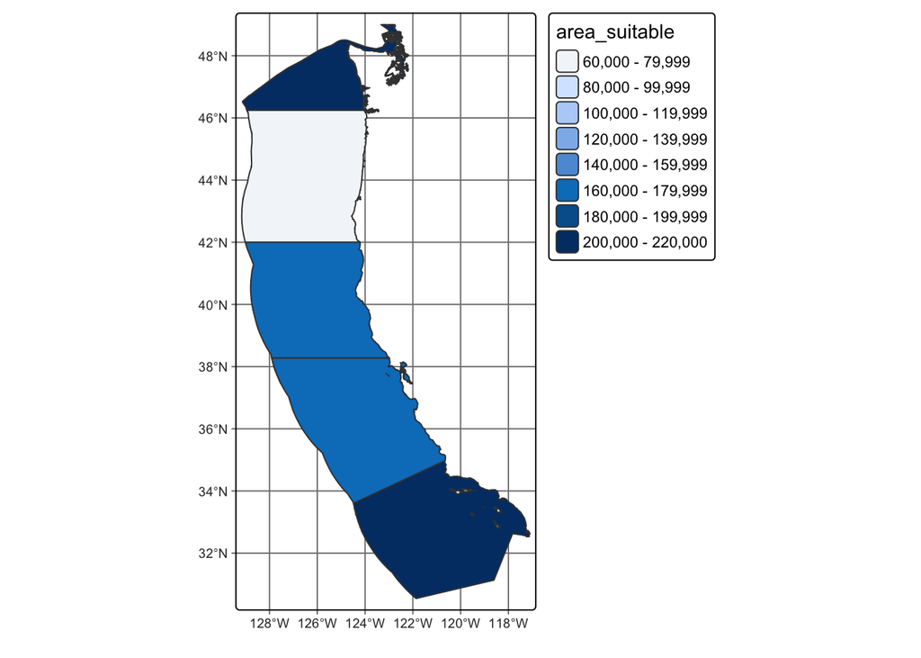

```r
# Make a map of suitable area within Economic Zones
tm_shape(zones_clean)+
  tm_graticules()+
  tm_polygons(fill = "area_suitable")
```

# Function from suitable area workflow

We must repeat the process above in a generalizable function in order to be able to pass any species information through and get the same result.

To break down the process, our code needs to…

With these data, the function must:

1. Ensure that all CRSs are the same for EEZ, SST, and depth.
2. Subtract 273.15 from the mean values of SST
3. Crop depth to the extent of SST.
4. Create matrix of max and min for SST and depth
5. Apply matrix to SST and depth raster
6. Multiply SST and depth suitable area rasters
7. Crop suitable area raster to EEZ.
8. Calculate zonal statistics for each EEZ based on suitable area.
9. Make map of suitable area in each zone as a color gradient.

## EEZ Suitable area function

We will use the workflow above to create a function that is generalizable to any species. The only requirements are that average sea surface temperature ranges are provided in Celsisus and as a raster, bathymetry is provided in meters as a raster, and that EEZ is a shapefile. Any user-specified data (minimum and maximum depth and sea surface temperature) must be in meters and Celsisus respectively.

```r
# Mean SST pre calculated and 273.15 subtracted if in Kelvin
eez_suitable_area <- function(mean_sst, bath, eez, min_sst, max_sst, min_depth, max_depth, species_name){

  # Ensure that all parameter are present
  if(missing(mean_sst)) stop("Error: 'mean_sst' argument is required")
  if(missing(bath)) stop("Error: 'bath' (bathymetry) argument is required")
  if(missing(eez)) stop("Error: 'eez' argument is required")
  if(missing(min_sst)) stop("Error: 'min_sst' argument is required")
  if(missing(max_sst)) stop("Error: 'max_sst' argument is required")
  if(missing(min_depth)) stop("Error: 'min_depth' argument is required")
  if(missing(max_depth)) stop("Error: 'max_depth' argument is required")
  if(missing(species_name)) stop("Error: 'species_name' argument is required")


  # Check that all data types are correct
  if(!inherits(mean_sst, "SpatRaster")) {
    stop("Error: 'mean_sst' must be a SpatRaster object")
  }
  if(!inherits(bath, "SpatRaster")) {
    stop("Error: 'bath' must be a SpatRaster object")
  }
  if(!inherits(eez, c("sf", "sfc"))) {
    stop("Error: 'eez' must be an sf or sfc object")
  }

  # Check that numeric and character data are correct
    # Check that numeric parameters are valid
  if(!is.numeric(min_sst) || !is.numeric(max_sst)) {
    stop("Error: min_sst and max_sst must be numeric values")
  }
  if(!is.numeric(min_depth) || !is.numeric(max_depth)) {
    stop("Error: min_depth and max_depth must be numeric values")
  }
  if(!is.character(species_name)) {
    stop("Error: species_name must be a character string")
  }


  # Reproject EEZ to match the CRS of SST
  eez_reproj <- st_transform(eez, crs(mean_sst))

  # Reproject bathymetry to match the CRS of SST
  bath_reproj <- project(bath, mean_sst)

  # Crop bathymetry to match the extent of the SST raster
  bath_crop <- crop(bath_reproj, mean_sst)

  # Ensure that resolutions match
  sst_reproj <- resample(bath_crop, mean_sst, method = "near")


  # Build a raster for suitable temperature
  # SST matrix
  sst_matrix <- matrix(c(-Inf,min_sst, 0,
                         min_sst, max_sst, 1,
                         max_sst, Inf, 0),
                       ncol = 3, byrow = TRUE)

  # Depth matrix
  depth_matrix <- matrix(c(-Inf, max_depth, 0,
                           max_depth, min_depth, 1,
                           min_depth, Inf, 0),
                         ncol = 3, byrow = TRUE)


  # Apply matrices to both rasters
  sst_reclassified <- classify(sst_reproj, rcl = sst_matrix)
  depth_reclassified <- classify(bath_reproj, rcl = depth_matrix)


  # Multiply both cells to get the suitable cells
  suitable_cells <- sst_reclassified * depth_reclassified


  # Convert 0s to NAs
  suitable_cells[suitable_cells == 0] <- NA


  # Crop suitable cells to EEZ
  suitable_cells_crop <- crop(suitable_cells, eez_reproj)


  # Make an EEZ raster
  eez_raster <- rasterize(eez_reproj, suitable_cells_crop, field = "area_km2")


  # Get the cell size from the suitable_area_crop raster
  suitable_cells_area <- cellSize(suitable_cells_crop,
                                  mask = TRUE,
                                  lyrs = FALSE,
                                  unit = "km"
                                  )


  # Conduct zonal statistics using the area of suitable cells
  zonal_suitable_cells <- zonal(suitable_cells_area,
                                eez_raster,
                                  fun = "sum",
                                  na.rm = TRUE)


  # Create a dataframe
  suitable_area_df <- cbind(eez, zonal_suitable_cells) |>
    select(rgn, area_km2, area_km2.1) |>
    rename(region = rgn,
         total_area = area_km2,
         suitable_area = area_km2.1)

  # Create tmap from dataframe
  map_of_suitable_area <- tm_shape(suitable_area_df) +
  tm_graticules() +
  tm_polygons(
    fill = "suitable_area",
    fill.legend = tm_legend(
      title = "Suitable Area (km²)",
      position = tm_pos_out("right")
    )
  ) +
  tm_title(paste("Area of suitable habitat for", species_name))


  # Call the map
  map_of_suitable_area

}
```

Now we want to test this workflow for Oysters.

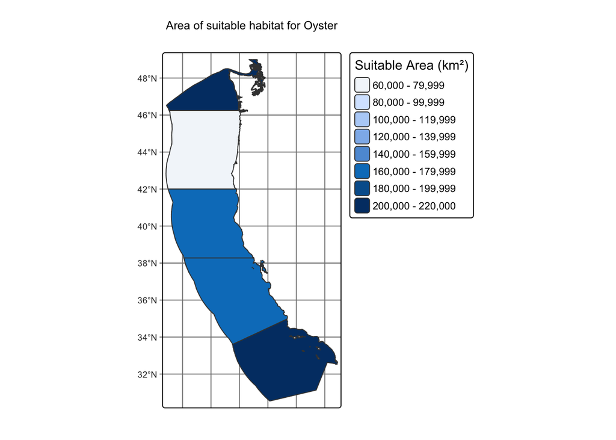

```r
# Pass the oyster information through the function
# function(mean_sst, bath, eez, min_sst, max_sst, min_depth, max_depth, species_name
eez_suitable_area(mean_sst = sst_c_mean, bath = bath, eez = eez,
                  min_sst = 11,
                  max_sst = 30,
                  min_depth = 0,
                  max_depth = -70,
                  species_name = "Oyster")
```

# P.interruptus (California spiny lobster)

Next, we will repeat this entire process for the California spiny lobster.

The California spiny lobster has an SST range between 10 to 21 Celsius and a depth range of 0 to 150 meters. We will use this information with our function to generate a map of suitable area for California spiny lobsters. This information comes from the [Seal Life Base](https://www.sealifebase.ca/summary/Panulirus-interruptus.html) website and Venter et al. 2008.

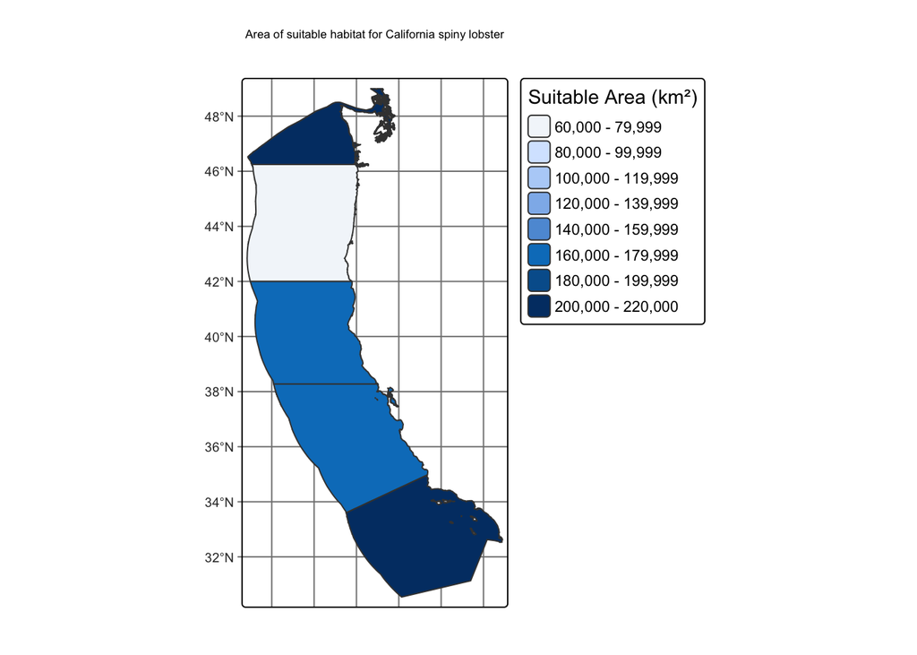

```r
# Plug California spiny lobsert information into
eez_suitable_area(mean_sst = sst_c_mean, bath = bath, eez = eez,
                  min_sst = 10,
                  max_sst = 21,
                  min_depth = 0,
                  max_depth = -150,
                  species_name = "California spiny lobster")
```

# Reflection

## References

Kolbert, J. (2015, April 2). Salmon and lobster aquaculture. *Bates College Biology Department*. https://www.bates.edu/biology/2015/04/02/salmon-and-lobster-aquaculture/

NOAA Fisheries. (n.d.). *Commercial shellfish aquaculture on the West Coast*. https://www.fisheries.noaa.gov/west-coast/aquaculture/commercial-shellfish-aquaculture-west-coast

Froese, R., & Pauly, D. (Eds.). (n.d.). *Panulirus interruptus* (Randall, 1840). SeaLifeBase. https://www.sealifebase.ca/summary/Panulirus-interruptus.html

Gentry, R. R., Froehlich, H. E., Grimm, D., Kareiva, P., Parke, M., Rust, M., Gaines, S. D., & Halpern, B. S. (2017). Mapping the global potential for marine aquaculture. *Nature Ecology & Evolution*, *1*(9), 1317–1324. https://doi.org/10.1038/s41559-017-0257-9

Venter, L., Booth, A. J., & Merwe, M. V. D. (2008). The effect of temperature on the growth, survival and food consumption of the east coast rock lobster *Panulirus homarus rubellus*. *Aquaculture*, *280*(1–4), 227–231. https://doi.org/10.1016/j.aquaculture.2008.05.002